# Trabajando con Datasets Externos

Manejo de datasets externos para saber las ventajas que hay al trabajar con estos hecho de manera manual o utilizando otros datasets ya formulados. Dos de los formatos que puede manejar Rstudio son: 1. HTML(Hypertext Markup Language) 2. CSV(Comma Separated Value)

Un ejemplo de uso de un dataset creado manualmente usando una imagen del precio del Grande Latte de Starbucks http://www.coventryleague.com/blogentary/the-starbucks-latte-index

```r
library(readr)
library(rpart)
LatteIndexFrame <- read_csv("LatteIndexFrame.csv")
```

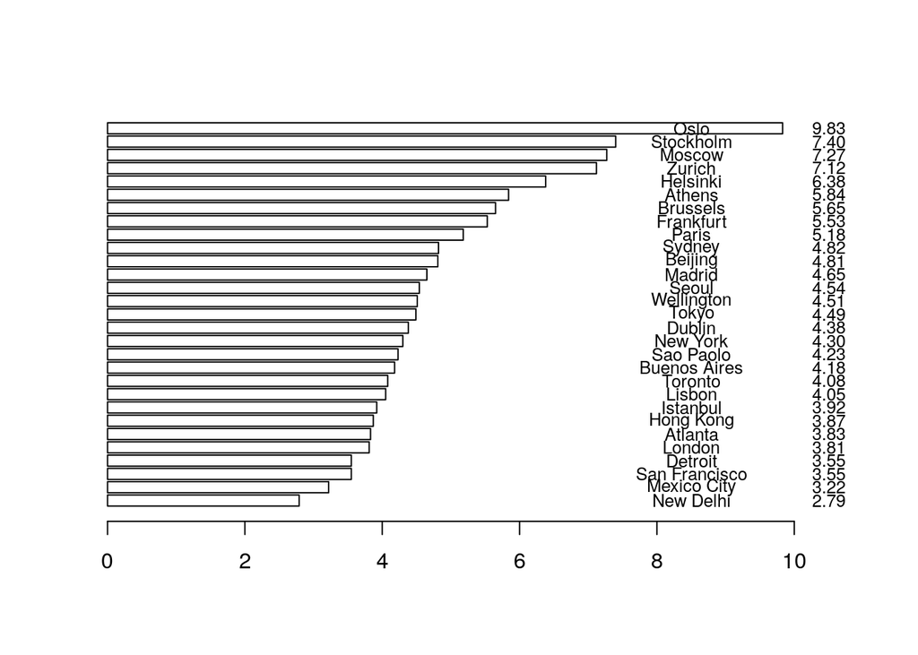

```r
Mids <- barplot(LatteIndexFrame$price, col="transparent",horiz = TRUE, xlim = c(0,11))
text(8.5,Mids,LatteIndexFrame$city,cex = 0.8)
text(10.5,Mids,format(LatteIndexFrame$price,nsmall=2), cex = 0.8)
```

## Administración de archivos en R

Para poder usar un archivo el programa tiene que encontrarse en el directorio en donde este se encuentra, a veces no solo es necesario eso si no que hay que crear o movernos entre directorios para eso estan los siguientes comandos.

```r
getwd() #Obtenemos la dirección actual donde se encuentra el programa.
```

```
## [1] "/home/jose/Escritorio/Maestria/Tercer Cuatrimestre/Said/Tarea 6.- Exposición Analisis de datos"
```

```r
setwd("..") #Para movernos a una carpeta dentro de nuestro directorio o atras
getwd()
```

```
## [1] "/home/jose/Escritorio/Maestria/Tercer Cuatrimestre/Said"
```

```r
setwd("../Tarea 6.- Exposición Analisis de datos")
getwd()
```

[output not shown]

```r
list.files() #Para obtener un listado de los archivos encontrados en el directorio actual.
```

```
##  [1] "(Chapman & Hall_CRC Data Mining and Knowledge Discovery Series) Ronald K. Pearson - Exploratory Data Analysis Using R-Chapman and Hall_CRC (2018).pdf"
##  [2] "auto-mpg.names"
##  [3] "AutoMpgBoxplotEx.pdf"
##  [4] "AutoMpgBoxplotEx.png"
##  [5] "BMfile2000-Jul2015.xls"
##  [6] "Dataset.csv"
##  [7] "Exposición_files"
##  [8] "Exposición.html"
##  [9] "Exposición.Rmd"
## [10] "holamundo.csv"
## [11] "LatteIndexFrame.csv"
## [12] "linearModelExample.rds"
## [13] "UCIautoMpg.txt"
## [14] "Unclaimed_Bank_Accounts-2.csv"
## [15] "Untitled.ipynb"
## [16] "WBCDDataset.csv"
```

```r
list.files(pattern = "Expo") #Obtener un listado de los archivos con caracteres comunes.
```

```
## [1] "Exposición_files" "Exposición.html"  "Exposición.Rmd"
```

## Colocar datos Manualmente

### Colocar datos a mano

Esta es una de las formas de hacer nuestro propio dataset, debido a que es una forma sencilla de trabajar y colocar datos como se hizo con el dataset del precio del latte grande de starbucks y puede servir como guía para empezar a trabajar.

### Es malo colocar los datos pero a veces hay excepciones

1. Es muy difícil colocar datos cuando es un conjunto muy largo de estos.
2. Podemos cometer un error al colocar los datos el cual cause que no sirva.

## Interactuando con el Internet

El internet nos ayuda a encontrar dataset para probar algunas metodos en nuestro programa en R, si bien R ya tiene un conjunto de dataset para empezar a programar es bueno saber como introducir nuevos datasets y trabajar con ellos.

### Previa vista de 3 ejemplos de datasets en Internet

- Distancia recorrida en millas de un automovil.

```r
browseURL("http://archive.ics.uci.edu/ml") #Nos abrirá una pestaña en el navegador a la dirección entre comillas.
URL <- "http://archive.ics.uci.edu/ml/machine-learning-databases/auto-mpg/auto-mpg.data"
download.file(URL, "UCIautoMpg.txt") #Nos descargará el dataset seleccionado
```

- Cuentas de bancos no reclamadas en Canada

```r
SocrataURL <- "https://opendata.socrata.com/"
browseURL(SocrataURL)
DownloadFile <- "C:/Users/Ron/Downloads/Unclaimed_bank_accounts.csv"
file.copy(DownloadFile, "Unclaimed_bank_accounts.csv")
```

```
## [1] FALSE
```

- Indice de economia de la BigMac

```r
Bigmac <- "http://www.economist.com/content/big-mac-index"
browseURL(Bigmac)
```

## Trabajando con Archivos CSV

Los archivos CSV son uno de los mas usados para la lectura de datos debido a su simplicidad al manejarlos y el gran numero de programas que pueden utilizarlos.

### Leer y escribir en un archivos CSV

La forma mas sencilla de leer y escribir en un archivos CSV es usando las funciones: 1. read.csv(“Nombre del archivo CSV”)

```r
WBCD <- read.csv("Dataset.csv")
head(WBCD)
```

```
##         ID MB Radio Textura Perimetro   Area Smoothness Compactness
## 1   842302  M 17.99   10.38    122.80 1001.0    0.11840     0.27760
## 2   842517  M 20.57   17.77    132.90 1326.0    0.08474     0.07864
## 3 84300903  M 19.69   21.25    130.00 1203.0    0.10960     0.15990
## 4 84348301  M 11.42   20.38     77.58  386.1    0.14250     0.28390
## 5 84358402  M 20.29   14.34    135.10 1297.0    0.10030     0.13280
## 6   843786  M 12.45   15.70     82.57  477.1    0.12780     0.17000
##   Concavity Concave.Points Symmetry Fractal.Dimention Radius.Error
## 1    0.3001        0.14710   0.2419           0.07871       1.0950
## 2    0.0869        0.07017   0.1812           0.05667       0.5435
## 3    0.1974        0.12790   0.2069           0.05999       0.7456
## 4    0.2414        0.10520   0.2597           0.09744       0.4956
## 5    0.1980        0.10430   0.1809           0.05883       0.7572
## 6    0.1578        0.08089   0.2087           0.07613       0.3345
##   Texture.Error Perimeter.Error AreasError Smoothness.Error
```

[output cut: 34 more lines]

2. write.csv(“Los datos”, “El nombre del archivo CSV”)

```r
write.csv(WBCD,"WBCDDataset.csv")
```

### Hojas de calculo vs archivos CSV no son lo mismo

1. Un archivo CSV es un simple archivo de datos, puede ser leido por Microsoft Excel y por muchos otros programas.
2. El programa de hoja de calculo de Microsoft Excel es un software que puede hacer muchas cosas, incluyendo leer y escribir archivos CSV, realizar computación simple de análisis de datos y generar gráficas.
3. Un archivo de datos de Microsoft Excel contiene los datos sobre los cuales una hoja de calculo se basa.

```r
library(xlsx)
BigMacJan2013 <- read.xlsx("BMfile2000-Jul2015.xls", sheetName = "Jan2013")
head(BigMacJan2013)
```

```
##     Country local_price   dollar_ex dollar_price  dollar_ppp
## 1 Argentina       19.00   4.9765000     3.817944   4.3504186
## 2 Australia        4.70   0.9590946     4.900455   1.0761562
## 3    Brazil       11.25   1.9933500     5.643766   2.5759057
## 4   Britain        2.69   0.6332120     4.248183   0.6159277
## 5    Canada        5.41   1.0029000     5.394356   1.2387244
## 6     Chile     2050.00 471.7500000     4.345522 469.3872683
##   dollar_valuation dollar_adj_valuation euro_adj_valuation
## 1       -12.580758            31.583765          9.1424392
## 2        12.205424            -3.442778        -19.9104025
## 3        29.224960            89.815124         57.4425667
## 4        -2.729621             6.361586        -11.7781520
## 5        23.514254            21.154868          0.4921682
## 6        -0.500844            43.103425         18.6974462
##   sterling_adj_valuation yen_adj_valuation yuan_adj_valuation
## 1              23.713617          59.93016         37.3100903
## 2              -9.217955          17.35804          0.7592459
## 3              78.462105         130.70600         98.0755902
## 4               0.000000          29.27450         10.9902803
## 5              13.908482          47.25462         26.4273439
## 6              34.544275          73.93144         49.3310684
```

### Problemas potenciales al usar archivos CSV en R.

- Cambio de nombres Debido a que R solo acepta variables con “.” y "_" al momento de querer leer un archivo CSV las variables que contengan caracteres no legibles se cambiaran por un punto.

```r
colnames(WBCD)
```

```
##  [1] "ID"                      "MB"
##  [3] "Radio"                   "Textura"
##  [5] "Perimetro"               "Area"
##  [7] "Smoothness"              "Compactness"
##  [9] "Concavity"               "Concave.Points"
## [11] "Symmetry"                "Fractal.Dimention"
## [13] "Radius.Error"            "Texture.Error"
## [15] "Perimeter.Error"         "AreasError"
## [17] "Smoothness.Error"        "Compactness.Error"
## [19] "Concavity.Error"         "Concave.Points.Error"
## [21] "Symmetry.Error"          "Fractal.Dimention.Error"
## [23] "Worst.Radius"            "Worst.Texture"
## [25] "Worst.Perimeter"         "Worst.Area"
## [27] "Worst.Smoothness"        "Worst.Compactness"
## [29] "Worst.Concavity"         "Worst.Concave.Points"
## [31] "Worst.Symmetry"          "Worst.Fractal.Dimension"
```

- Problemas de comas incrustadas Hay ocaciones en que al guardar un archivo CSV con algunas comas hace que en veces de separar en 2 columnas nos agrega todo en una sola y esto hace que ocurra el siguiente error.

```r
library(sqldf)
```

```r
unclaimedLines <- readLines("Unclaimed_Bank_Accounts-2.csv")
line8 <- unclaimedLines[5]
strsplit(line8, split = ",")
```

```
## [[1]]
## [1] "KELM"                   "SELMA       "
## [3] "67510.34"               "09/08/1995 12:00:00 AM"
## [5] "BANK OF MONTREAL "
```

## Trabajando con otro tipo de archivos

Los archivos de texto (.txt) son leidos por la funcion “readLines()”, esta funcion es usada cuando se quiere leer lineas en especifico de archivo y los archivos txt son perfectos para esto.

```r
autoMpgRecords <- readLines("UCIautoMpg.txt")
x <- autoMpgRecords[1]
nchar(x)  #Numero de caracteres
```

```
## [1] 15
```

```r
substr(x, 1, 56) #Limite de comienzo (1) y fin (56) de lectura de caracteres
```

```
## [1] "<!DOCTYPE html>"
```

```r
substr(x, 57, 84)
```

```
## [1] ""
```

```r
autoMpgNames <- readLines("auto-mpg.names")
autoMpgNames[32:44]
```

```
##  [1] "7. Attribute Information:"
##  [2] ""
##  [3] "    1. mpg:           continuous"
##  [4] "    2. cylinders:     multi-valued discrete"
##  [5] "    3. displacement:  continuous"
##  [6] "    4. horsepower:    continuous"
##  [7] "    5. weight:        continuous"
##  [8] "    6. acceleration:  continuous"
##  [9] "    7. model year:    multi-valued discrete"
## [10] "    8. origin:        multi-valued discrete"
## [11] "    9. car name:      string (unique for each instance)"
## [12] ""
## [13] "8. Missing Attribute Values:  horsepower has 6 missing values"
```

### Guardando y Abriendo objetos de R

El guardado de objetos de R nos ayuda a no perder estos objetos que podríamos utilizar en otras secciones de R ya que al momento de cerrar el programa estos objetos desaparecen. Para guardas estas funciones se utilizan la siguiente función: 1. saveRDS(“objeto”, “nombre del archivo.rds”) 2. readRDS(“Nombre del archivo.rds”)

```r
linearModel <- lm(mpg ~ ., data = mtcars)
names(linearModel)
```

```
##  [1] "coefficients"  "residuals"     "effects"       "rank"
##  [5] "fitted.values" "assign"        "qr"            "df.residual"
##  [9] "xlevels"       "call"          "terms"         "model"
```

```r
saveRDS(linearModel, "linearModelExample.rds")
recoveredLinearModel <- readRDS("linearModelExample.rds")
identical(recoveredLinearModel, linearModel)
```

```
## [1] TRUE
```

### Archivos de Gráficas

Función para guardar gráficas a archivos pdf.

```r
pdf("AutoMpgBoxplotEx.pdf")
  boxplot(Area ~ AreasError, data = WBCD,
          xlab = "Area", ylab = "AreasError",
          las = 1, varwidth = TRUE)
dev.off()
```

También se pueden guardar gráficas en forma de imagenes.

```r
png("AutoMpgBoxplotEx.png")
  boxplot(Area ~ AreasError, data = WBCD,
          xlab = "Area", ylab = "AreasError",
          las = 1, varwidth = TRUE)
dev.off()
```

## Fucionando Datos de diferentes fuentes

En ciertas ocaciones es útil juntar un dos dataset diferentes para ver información de utilidad y para esto se usa la funcion merge(“Primer dataset”,“Segundo dataset”, by.x = “Atributo del primero”, by.y = “Atributo del segundo”)

```r
FlawedMergeFrame <- merge(LatteIndexFrame, BigMacJan2013, by.x="country", by.y="Country")
```

La forma de ordenar mejor la union es la siguiente:

```r
LatteSubset <- data.frame(country = as.character(LatteIndexFrame$country),
                          city = as.character(LatteIndexFrame$city),
                          GrandeLatteIndex = LatteIndexFrame$price,
                          stringsAsFactors = FALSE)
BigMacSubset <- data.frame(country = as.character(BigMacJan2013$Country),
                          BigMacIndex = BigMacJan2013$dollar_price,
                          stringsAsFactors = FALSE)
BetterMerge <- merge(LatteSubset, BigMacSubset)
str(BetterMerge, vec.len = 2)
```

```
## 'data.frame':    28 obs. of  4 variables:
##  $ country         : chr  "Argentina" "Australia" ...
##  $ city            : chr  "Buenos Aires" "Sydney" ...
##  $ GrandeLatteIndex: num  4.18 4.82 5.65 4.23 3.87 ...
##  $ BigMacIndex     : num  3.82 4.9 ...
```

Para observar cuales son las diferencias que hay entre los dos datasets se usa lo siguiente:

```r
setdiff(LatteSubset$country, BetterMerge$country)
```

```
## [1] "England"
```

Para cambiar el string usamos el siguiente codigo:

```r
EnglandIndex <- which(LatteSubset$country == "England")
LatteSubset$country[EnglandIndex] <- "Britain"
FinalMerge <- merge(LatteSubset, BigMacSubset)
str(FinalMerge, vec.len=2)
```

```
## 'data.frame':    29 obs. of  4 variables:
##  $ country         : chr  "Argentina" "Australia" ...
##  $ city            : chr  "Buenos Aires" "Sydney" ...
##  $ GrandeLatteIndex: num  4.18 4.82 5.65 4.23 3.81 ...
##  $ BigMacIndex     : num  3.82 4.9 ...
```

## Una pequeña introducción a las bases de datos

### Bases de datos relacionales, consultas y SQL

1. Las bases de datos son diseñadas: esto involucra decidir que variables son incluidas y como seran oraganizadas.
2. El diseño de bases de datos son implementados en un entorno especifico de un software, en el cual implique crear y poblar la tabla de datos, proporcionando aceso a los datos.
3. Correr el Consultador SQL para volver a extraer de la base de datos un dato especifico que se necesite.

### Una Introducción a el paquete SQLDF

```r
library(sqldf)
strangeCars <- sqldf("SELECT city , price, country
                      FROM LatteIndexFrame
                      WHERE price > 3 AND price < 5") # o cambiar Where por GROUP BY
strangeCars
```

```
##             city price       country
## 1    Mexico City  3.22        Mexico
## 2  San Francisco  3.55 United States
## 3        Detroit  3.55 United States
## 4         London  3.81       England
## 5        Atlanta  3.83 United States
## 6      Hong Kong  3.87         China
## 7       Istanbul  3.92        Turkey
## 8         Lisbon  4.05      Portugal
## 9        Toronto  4.08 United States
## 10  Buenos Aires  4.18     Argentina
## 11     Sao Paolo  4.23        Brazil
## 12      New York  4.30 United States
## 13        Dublin  4.38       Ireland
## 14         Tokyo  4.49         Japan
## 15    Wellington  4.51   New Zealand
## 16         Seoul  4.54   South Korea
## 17        Madrid  4.65         Spain
## 18       Beijing  4.81         China
## 19        Sydney  4.82     Australia
```

También cuenta con unión entre bases de datos usando el siguiente programa:

```r
query <- "SELECT Lsub.country, Lsub.city, Lsub.GrandeLatteIndex, Msub.BigMacIndex
FROM LatteSubset AS Lsub INNER JOIN BigMacSubset AS Msub
ON Lsub.country = Msub.country"
IndexFrame <- sqldf(query)
head(IndexFrame)
```

```
##         country          city GrandeLatteIndex BigMacIndex
## 1         India     New Delhi             2.79    1.666823
## 2        Mexico   Mexico City             3.22    2.904603
## 3 United States San Francisco             3.55    4.367396
## 4 United States       Detroit             3.55    4.367396
## 5       Britain        London             3.81    4.248183
## 6 United States       Atlanta             3.83    4.367396
```

```r
library(RSQLite)
conn <- dbConnect(SQLite(), "EconomicIndexDatabase.db")
dbWriteTable(conn, "GrandeLatteTable", LatteSubset)
dbWriteTable(conn, "BigMacTable", BigMacSubset)
```

```r
dbListTables(conn)
```

```
## [1] "BigMacTable"      "GrandeLatteTable"
```

```r
dbListFields(conn, "GRANDELATTETABLE")
```

```
## [1] "country"          "city"             "GrandeLatteIndex"
```

```r
dbListFields(conn, "bigmactable")
```

```
## [1] "country"     "BigMacIndex"
```

```r
dbGetQuery(conn, "SELECT COUNT(*) AS 'GrandeLatteRowCount' FROM GrandeLatteTable")
```

```
##   GrandeLatteRowCount
## 1                  29
```

```r
dbGetQuery(conn, "SELECT COUNT(*) AS 'BigMacRowCount' FROM BigMacTable")
```

```
##   BigMacRowCount
## 1             57
```

```r
query <- "SELECT M.country, M.BigMacIndex FROM BigMacTable AS M
WHERE M.country IN (SELECT country FROM GrandeLatteTable)"
BigMacBoth <- dbGetQuery(conn, query)
```

```r
query <- "SELECT M.country, M.BigMacIndex FROM BigMacTable AS M
WHERE M.country NOT IN (SELECT country FROM GrandeLatteTable)"
BigMacOnly <- dbGetQuery(conn, query)
dbDisconnect(conn)
```

# Model de Regresión Lineal

Los modelos predictivos son modelos matemáticos que nos permiten predecir algunas variables de interes desde una o mas variables que se cree se relacionan.

## Modelando los datos de Witeside

```r
library(MASS)
summary(whiteside)
```

```
##     Insul         Temp             Gas
##  Before:26   Min.   :-0.800   Min.   :1.300
##  After :30   1st Qu.: 3.050   1st Qu.:3.500
##              Median : 4.900   Median :3.950
##              Mean   : 4.875   Mean   :4.071
##              3rd Qu.: 7.125   3rd Qu.:4.625
##              Max.   :10.200   Max.   :7.200
```

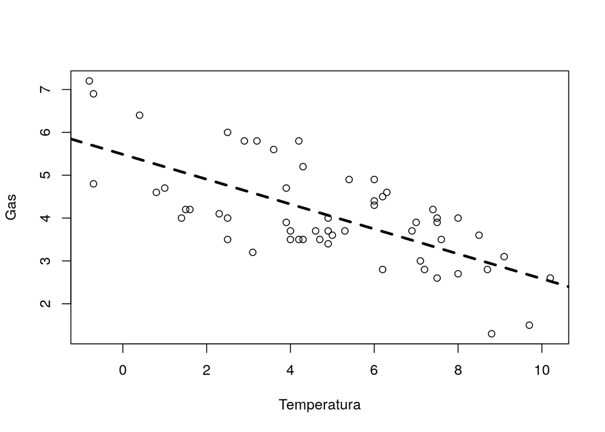

```r
par(mfrow=c(1,1))
x <- whiteside$Temp
y <- whiteside$Gas
plot(x, y, xlab = "Temperatura", ylab = "Gas")
olsModel <- lm(y ~ x)
abline(olsModel, lty = 2,lwd = 3)
```

### Describiendo lineas en el plano

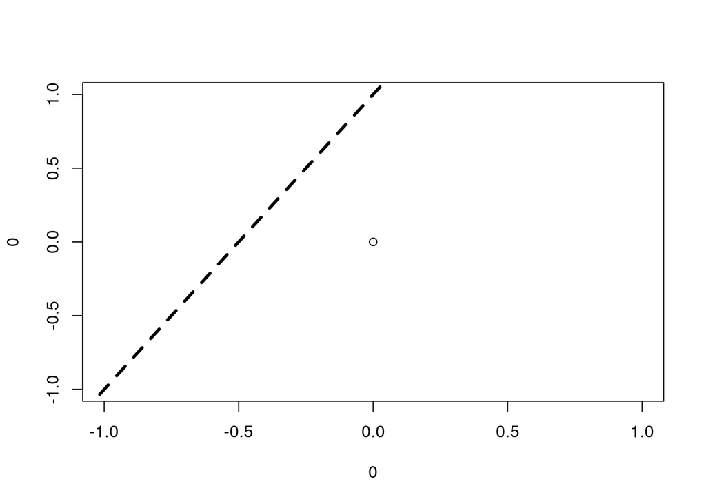

```r
plot(0,0)
abline(a=1, b=2, lty=2, lwd=3)
```

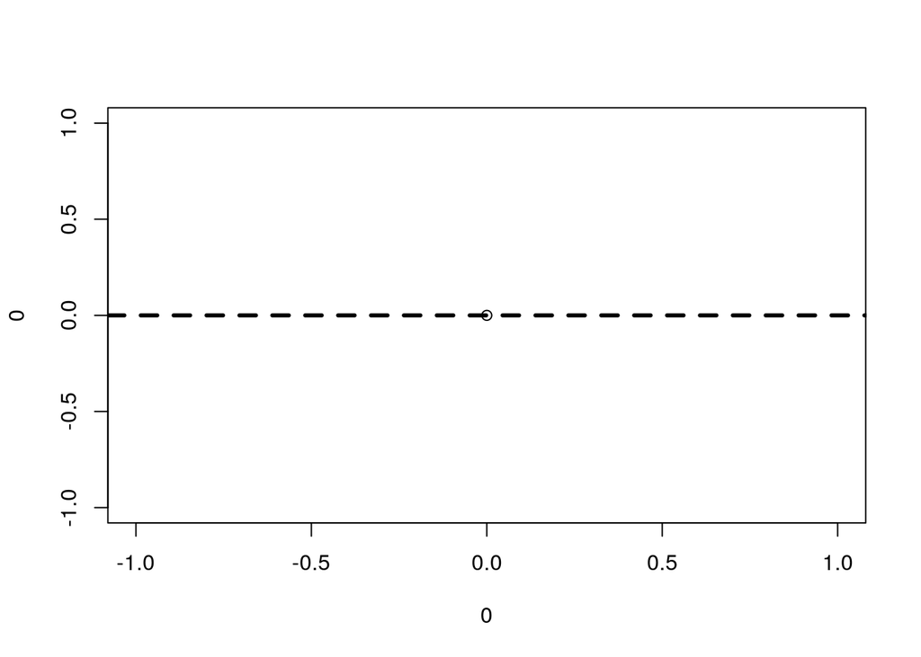

```r
plot(0,0)
abline(a=0,b=0, lty=2, lwd=3)
```

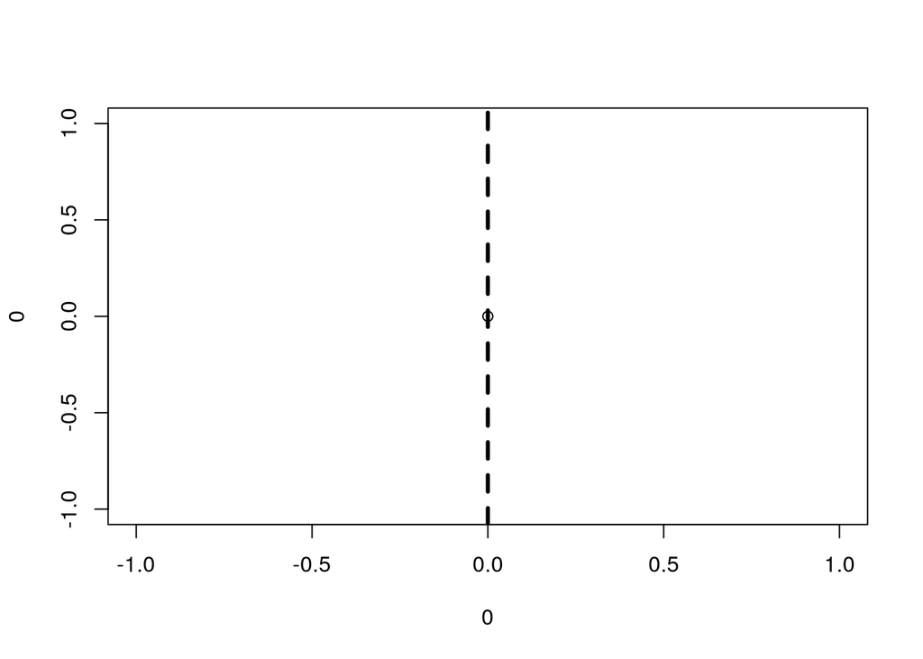

```r
plot(0,0)
abline(v=0, lty=2, lwd=3)
```

```r
linearModelA <- lm(Gas ~ Temp, data = whiteside)
names(linearModelA)
```

```
##  [1] "coefficients"  "residuals"     "effects"       "rank"
##  [5] "fitted.values" "assign"        "qr"            "df.residual"
##  [9] "xlevels"       "call"          "terms"         "model"
```

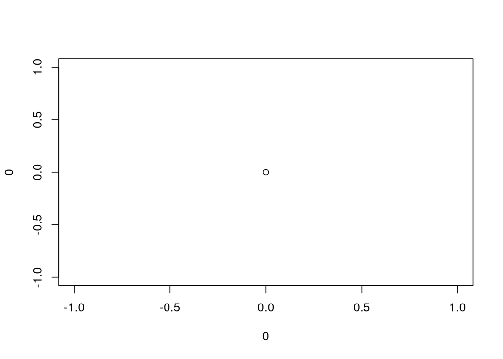

```r
plot(0,0)
abline(linearModelA, lty = 2, lwd = 2)
```

```r
linearModelA$coefficients
```

```
## (Intercept)        Temp
##   5.4861933  -0.2902082
```